# Selenium 사용하기

- 크롬 115이상 버전부터 부터 드라이버 설치 불필요
- 셀레니움4 부터 문법 변경
- https://www.selenium.dev/documentation/

셀레니움으로는 스크래핑하면 너무 느리므로, 동적 웹페이지 접속 및 이벤트 발생 역할 만 하고, 파싱은 BS4를 쓰는게 좋다.

```python
# 셀레니움 라이브러리 설치
!pip install selenium
```

```python
from selenium import webdriver
from selenium.webdriver.common.by import By
from selenium.webdriver.chrome.options import Options
import time

options = Options()
# options.add_argument("--start-maximized")
# options.add_argument("--headless=new")
options.add_experimental_option("detach", True) #특정함수안에서  드라이버 생성시 함수종료될 때 브라우저 같이 종료되는 문제 대응
```

## 브라우저 실행 및 페이지 접속

```python
url = 'http://naver.com'
driver = webdriver.Chrome(options=options) # 객체 생성

driver.get(url) # 실행

time.sleep(2)
```

## 상호작용

```python
driver.back()
```

```python
driver.forward()
```

```python
driver.refresh()
```

## 페이지 정보 가져오기

```python
title = driver.title
url = driver.current_url
handle = driver.current_window_handle
print(title, url, handle)
```

```
NAVER https://www.naver.com/ 68D44E3B7A306F99A67EF69A91837A96
```

## html 요소 찾기

네이버 검색창을 핸들링해보자 driver.find_element().send_keys()

```
<input id="query" name="query" type="search" title="검색어를 입력해 주세요." placeholder="검색어를 입력해 주세요." maxlength="255" autocomplete="off" class="search_input" data-atcmp-element="">
```

```python
driver.find_element?
```

```
Signature: driver.find_element(by='id', value: Optional[str] = None) -> selenium.webdriver.remote.webelement.WebElement
Docstring:
Find an element given a By strategy and locator.

:Usage:
    ::

        element = driver.find_element(By.ID, 'foo')

:rtype: WebElement
File:      c:\users\maeng\anaconda3\lib\site-packages\selenium\webdriver\remote\webdriver.py
Type:      method
```

```python
driver.find_element(By.ID, "query")
```

```
<selenium.webdriver.remote.webelement.WebElement (session="759ac8c9a5f89e71de0bcd4bf060693a", element="f.8F1AF4C5CFE2D5CA43960FCD78C41BC3.d.9361EC46FD5E5CB39A9102558CEB3D9B.e.69")>
```

```python
# 키입력
driver.find_element(By.ID, "query").send_keys('뉴진스')
```

```python
driver.find_element(By.CLASS_NAME, "search_input").send_keys('블랙핑크')
```

```python
driver.find_element(By.NAME, "query").send_keys('르세라핌')
```

```python
driver.find_element(By.CSS_SELECTOR, ".search_input").send_keys('세븐틴')
```

```python
driver.find_element(By.CSS_SELECTOR, "#query").send_keys('에스파')
```

```python
driver.find_element(By.CSS_SELECTOR, "[title='검색어를 입력해 주세요.']").send_keys('트와이스')
```

```python
driver.find_element(By.CSS_SELECTOR, "[placeholder='검색어를 입력해 주세요.']").send_keys('트와이스')
```

```python
driver.find_element(By.XPATH,"//*[@id='query']").send_keys('BTS')
```

## 클릭

네이버 쇼핑 메뉴를 클릭해보자 driver.find_element().click()

[figure not shown]

```python
driver.find_element(By.LINK_TEXT, '쇼핑')
```

```
<selenium.webdriver.remote.webelement.WebElement (session="59bc046180df4d6513c068e1b87ac5c1", element="f.68D44E3B7A306F99A67EF69A91837A96.d.FA2972530FD3B9C5C0BCF6B45927E8DB.e.166")>
```

```python
driver.find_element(By.LINK_TEXT, '쇼핑').click()
```

```python
# 일부 매칭
driver.find_element(By.PARTIAL_LINK_TEXT, '쇼').click()
```

```python
# 태그는 너무 요소가 많으므로, 정확하게 대상을 찾을 때에는 안씀
driver.find_element(By.TAG_NAME, 'div')
```

```python
# 여러개의 요소를찾을 때
links = driver.find_elements(By.CSS_SELECTOR, '.link_service')
```

```python
for link in links:
    print(link)
```

```
<selenium.webdriver.remote.webelement.WebElement (session="59bc046180df4d6513c068e1b87ac5c1", element="f.68D44E3B7A306F99A67EF69A91837A96.d.FA2972530FD3B9C5C0BCF6B45927E8DB.e.7422")>
<selenium.webdriver.remote.webelement.WebElement (session="59bc046180df4d6513c068e1b87ac5c1", element="f.68D44E3B7A306F99A67EF69A91837A96.d.FA2972530FD3B9C5C0BCF6B45927E8DB.e.158")>
<selenium.webdriver.remote.webelement.WebElement (session="59bc046180df4d6513c068e1b87ac5c1", element="f.68D44E3B7A306F99A67EF69A91837A96.d.FA2972530FD3B9C5C0BCF6B45927E8DB.e.162")>
<selenium.webdriver.remote.webelement.WebElement (session="59bc046180df4d6513c068e1b87ac5c1", element="f.68D44E3B7A306F99A67EF69A91837A96.d.FA2972530FD3B9C5C0BCF6B45927E8DB.e.166")>
<selenium.webdriver.remote.webelement.WebElement (session="59bc046180df4d6513c068e1b87ac5c1", element="f.68D44E3B7A306F99A67EF69A91837A96.d.FA2972530FD3B9C5C0BCF6B45927E8DB.e.170")>
<selenium.webdriver.remote.webelement.WebElement (session="59bc046180df4d6513c068e1b87ac5c1", element="f.68D44E3B7A306F99A67EF69A91837A96.d.FA2972530FD3B9C5C0BCF6B45927E8DB.e.174")>
<selenium.webdriver.remote.webelement.WebElement (session="59bc046180df4d6513c068e1b87ac5c1", element="f.68D44E3B7A306F99A67EF69A91837A96.d.FA2972530FD3B9C5C0BCF6B45927E8DB.e.178")>
<selenium.webdriver.remote.webelement.WebElement (session="59bc046180df4d6513c068e1b87ac5c1", element="f.68D44E3B7A306F99A67EF69A91837A96.d.FA2972530FD3B9C5C0BCF6B45927E8DB.e.182")>
<selenium.webdriver.remote.webelement.WebElement (session="59bc046180df4d6513c068e1b87ac5c1", element="f.68D44E3B7A306F99A67EF69A91837A96.d.FA2972530FD3B9C5C0BCF6B45927E8DB.e.186")>
<selenium.webdriver.remote.webelement.WebElement (session="59bc046180df4d6513c068e1b87ac5c1", element="f.68D44E3B7A306F99A67EF69A91837A96.d.FA2972530FD3B9C5C0BCF6B45927E8DB.e.7423")>
<selenium.webdriver.remote.webelement.WebElement (session="59bc046180df4d6513c068e1b87ac5c1", element="f.68D44E3B7A306F99A67EF69A91837A96.d.FA2972530FD3B9C5C0BCF6B45927E8DB.e.7424")>
```

```python
# https://www.browserstack.com/guide/get-html-source-of-web-element-in-selenium-webdriver
# 해당 클래스가 속한 요소의 자식 html을 출력
for link in links:
    print(link.get_attribute("href"))
    print()
```

```
https://mail.naver.com/

https://cafe.naver.com/

https://blog.naver.com/

https://shopping.naver.com/home

https://news.naver.com/

https://finance.naver.com/

https://land.naver.com/

https://map.naver.com/

https://comic.naver.com/

https://chzzk.naver.com/

https://www.naver.com/#
```

## 자동 로그인 연습

```python
# 테스트용 html
# url = 'file:///C:/workspace/python/WASSUP/02_Data_Collection/sample/signin.html'
url = 'file:///C:/workspace/WASSUP2/WASSUP2/02_Data_Collection/sample/signin.html'
driver = webdriver.Chrome(options=options)
driver.get(url)
time.sleep(2)
```

```python
username = driver.find_element(By.NAME, "username")
username.send_keys('korea')
```

```python
username = driver.find_element(By.NAME, "password")
username.send_keys('1004')
```

```python
login =  driver.find_element(By.XPATH, '//*[@id="loginForm"]/input[3]')
login.click()
```

```python
driver.back()
```

```python
login =  driver.find_element(By.CSS_SELECTOR, "#loginForm > input[type=submit]:nth-child(5)")
login.click()
```

```python
driver.back()
```

```python
login =  driver.find_element(By.CSS_SELECTOR, "[value='Login']")
login.click()
```

```python
driver.back()
```

```python
# 입력창 clear 하기
# 세션끊기면 다시 접근해야함
username = driver.find_element(By.NAME, "username")
username.clear()
```

```python
username.submit()
```

```python
driver.back()
```

```python
driver.find_element(By.TAG_NAME, 'p').text
```

```
'Are you sure you want to do this?'
```

```python
# html 소스 가져오기
driver.page_source
```

```
'<html><head></head><body>\n        <h1> Sign In </h1>\n        <form action="moved.html" id="loginForm">\n            ID : <input name="username" type="text"> <br>\n            Password : <input name="password" type="password"> <br>\n\n            <input name="continue" type="submit" value="Login">…
```

```python
driver.close()
```

## options

```python
from selenium import webdriver
from selenium.webdriver.common.by import By
from selenium.webdriver.chrome.options import Options
import time

options = Options()
options.add_argument("--headless=new")
# options.add_argument('--window-size= x, y') #실행되는 브라우저 크기를 지정할 수 있습니다.
# options.add_argument('--start-maximized') #브라우저가 최대화된 상태로 실행됩니다.
# options.add_argument('--start-fullscreen') #브라우저가 풀스크린 모드(F11)로 실행됩니다.
# options.add_argument('--blink-settings=imagesEnabled=false') #브라우저에서 이미지 로딩을 하지 않습니다.
# options.add_argument('--mute-audio') #브라우저에 음소거 옵션을 적용합니다.
# options.add_argument('incognito') #시크릿 모드의 브라우저가 실행됩니다.
options.add_experimental_option("detach", True) #특정함수안에서  드라이버 생성시 함수종료될 때 브라우저 같이 종료되는 문제 대응
```

```python
url = 'http://naver.com'
driver = webdriver.Chrome(options=options)
driver.get(url)
time.sleep(2)
```

```python
print(driver.title)
```

```
NAVER
```

```python
driver.quit() # 탭 닫기
```

## 윈도우 컨트롤

```python
from selenium import webdriver
from selenium.webdriver.common.by import By
from selenium.webdriver.chrome.options import Options
import time

options = Options()
# options.add_argument("--start-maximized")
# options.add_argument("--headless=new")
options.add_experimental_option("detach", True) #

url = 'http://naver.com'
driver = webdriver.Chrome(options=options)
driver.get(url)
time.sleep(2)
```

### 창의 너비/높이 구하기

```python
size = driver.get_window_size()
width = size.get("width")
height = size.get("height")

print(str(width)+"px"+" "+str(height)+"px")
```

```
974px 1047px
```

### 창 크기 조절

```python
driver.set_window_size(800, 600)
```

### 스크린 상에서의 창 좌표

```python
position = driver.get_window_position()
x = position.get('x')
y = position.get('y')

print("x : "+str(x)+" "+"y : "+str(y))
```

```
x : -7 y : 0
```

```python
driver.set_window_position(200,200)
```

```
{'height': 600, 'width': 800, 'x': 200, 'y': 200}
```

```python
# 창 크기 최대화
driver.maximize_window()
```

```python
# 창 크기 최소화
driver.minimize_window()
```

```python
# 전체 화면
driver.fullscreen_window()
```

```python
# 스크린 샷
driver.save_screenshot('./image.png')
```

```
True
```

```python
driver.close()
```

# 예제) 네이버 블로그

```python
from selenium import webdriver
from selenium.webdriver.common.by import By
from selenium.webdriver.chrome.options import Options
import time, random, pandas as pd

options = Options()
options.add_argument('--window-size=974,1047')
options.add_argument('--window-position=-7,0')
options.add_experimental_option("detach", True)
```

```python
# 웹드라이버 로드
driver = webdriver.Chrome( options = options)
```

```python
# 조건 설정
where = 'blog'
query = '인공지능'
dateform = '20240101to20240318'
url = f'https://search.naver.com/search.naver?ssc=tab.{where}.all&query={query}&sm=tab_opt&nso=so%3Ar%2Cp%3Afrom{dateform}'
# url = f'https://search.naver.com/search.naver?where={where}&query={query}&sm=tab_op&nso=so:r,p:from{dateform}'
fname = f'{where}_{query}_{dateform}'
```

```python
# url 접속
driver.get(url)
time.sleep(random.randint(2,3))
```

## excute_script()

자바스크립트 함수(스크롤다운) 실행하기 execute_script("스크립트", 요소) 해당 페이지에 스크립트를 만들 때 사용합니다. 요소는 필수 파라미터는 아니고 요소가 있으면 요소에 스크립트가 실행되고 없으면 전체 페이지에 스크립트가 움직입니다.

```
js코드를 인자로 넣을 수 있어 브라우저 화면을 제어 할수 있게 된다. 스크롤을 하기 위해 뿐만아니라 다른 동적이벤트를 작성할 수 있다.

* 화면상 스크롤 위치 이동 : scrollTo(x,Y) ,scrollTo(x,Y+number)
* 화면 최하단으로 스크롤 이동 : scrollTo(0, document.body.scrollHeight)
* 화면을 움직이고 페이지 로드 기다리기 : time.sleep(second)
* 함수 호출시 전달인자들이 배열 형태로 저장된 객체 : arguments
    * (arguments[0].click(), sample)
    * sample요소의 첫번째 인자에 click()을 명령
```

```python
#네이버 뷰는 최대 1050까지만 노출
# 스크롤 10번
for i in range(10):
    driver.execute_script('window.scrollTo(0, document.body.scrollHeight);')
    time.sleep(random.randint(2, 3))
```

```python
# get_view()
views = driver.find_elements(By.CSS_SELECTOR, '.lst_view .bx')
result = []

for view in views:
    con_dict = {}
    con_dict['title'] = view.find_element(By.CSS_SELECTOR, '.title_link').text
    con_dict['text'] = view.find_element(By.CSS_SELECTOR, '.dsc_link').text
    con_dict['date'] = view.find_element(By.CSS_SELECTOR, '.sub').text
    result.append(con_dict)
    print(con_dict)

print('완료')
```

```
{'title': 'AI 인공지능 관련주 TOP 10 미국주식에 투자하는 국내 ETF', 'text': "(페이스북, 애플, 아마존, 넷플릭스, 구글) 최근에는 AI 위주의 투자가 주목받으면서 FAANG에서 넷플릭스가 제외되고 최대 AI 인공지능 관련주 엔비디아, 테슬라, 마이크로소프트가 포함된 'M7'(Magnificent7)이라는 용어를 많이 사용하고 있습니다. 하지만 M7 기업이라고해서 모두 주가 상승을 기록하고 있는 것은 아닙니다. 실제로 최대 관련주 엔비디아가...", 'date': '2주 전'}
{'title': '최신 무선 엘지 올레드TV 결국 인공지능 65인치와 77인치 가격차이!! 엘지 시그니처 올레드T 기대되네...', 'text': '그리고 기본적으로 인공지능 기능을 강화하면서 더욱 강력한 퍼포먼스를 제공합니다. 개인적으로는 부담이 되기는 하지만 올레드TV의 사이즈는 크면 클수록 좋다는... 2024년 최신 올레드TV의 혁신 핵심 요소는 성능을 대폭 강화한 신규 프로세서입니다. 전 모델보다 딥러닝 기능을 더욱 강화해 더 선명한 화질과 풍성한 공간...', 'date': '3주 전'}
{'title': '슈퍼마이크로컴퓨터(SMCI) 주가, 인공지능, 데이터센터 관련주', 'text': '안녕하세요 저장 안해서 같은 포스팅을 두번째 작성하는 네이버 인플루언서 길짱입니다 최근 AI 관련주가 굉장히 핫한데요 특히 전세계 증시 대장 미국 증권시장에 속한 인공지능... 슈퍼마이크로컴퓨터는 및 GPU 시장 대장인 엔비디아와 긴밀한 협력 관계를 구축하고 있어 엔비디아 관련주로 분류됩니다 또한 CPU 및 GPU 가속기 분야에서 엔비디아뿐 아니라...', 'date': '4주 전'}
{'title': '[2월 26일 마감시황] 인공지능(AI) 테마 추가 반등은 아직', 'text': "바탕으로 인공지능(AI) 테마가 주식시장 상승 모멘텀을 끌고 갈 것이란 기대가 높기는 하지만 본격적인 추가 반등은 아직 현실로 나타나지 않고 있음 '월가 공포지수' 변동성 지수(VIX)는 보합세 업종별로는 혼조세 테슬라가 포진한 임의소비재와 에너지, 엔비디아 등이 들어가 있는 기술업종이 상승 (AI) 시장 경쟁이 심화하는 가운데 검색시장...", 'date': '3주 전'}
{'title': '인공지능 기반 AI 로봇 똘똘이 로아이젠 돌봄 로봇 마이봄 미니 써보니', 'text': '인공지능 시스템이 우리 일상에 어느 정도 자리 잡아 나가고 있습니다. AI 로봇이 등장한 이후, 편리함을 추구함과 동시에 추후 휴머니즘이 사라질지도 모른다는 우려 때문인지 양날의 검이라 생각하시는 분들이 많습니다. 하지만 이는 앞으로 풀어나가야 할 과제겠죠. 각설하고 이번 포스팅에서 소개하려는 제품은 기반 AI 로봇 똘똘이 로아이젠 돌봄 로봇...', 'date': '2023.11.16.'}
{'title': '인공지능 AI 반도체 관련주 미국 국내 (1편)', 'text': '인공지능 AI 반도체 관련주 미국, 국내 미국 엔비디아 주가가 연일 폭등하고 있어서 AI 반도체에 대해 이야기를 해보려고 합니다. AI 반도체를 글 한편에 모두 설명하기에는 얽혀 있는 기업들도 많고 그 먹이 사슬을 이해하는 데만 해도 너무 정보가 방대하기 때문에 앞으로 AI 반도체 글을 시리즈 형식으로 나눠서 올릴 생각입니다~ 1. AI 가 대세 * 현재...', 'date': '4주 전'}
{'title': '리벨리온 인공지능 AI 반도체 주식 상장 주가 - NPU 관련주', 'text': '리벨리온 인공지능 AI 반도체 주식 상장 주가 - NPU 관련주 반도체 산업은 두 부류로 나뉩니다. 반도체를 설계하고 디자인 하는 쪽과, 이걸 실제 공장에서 찍어내는 쪽입니다. 전자를... 엔비디아가 급성장한 이유는 분야에 절대적으로 필요한 반도체 설계기술을 가지고 있기 때문입니다. AI 를 학습하고 동작시키기 위해서는 엄청나게 많은 부동소수점...', 'date': '4일 전'}
{'title': '월요일 메타, TSMC, AMD 및 인공지능 관련 주가가 하락한 이유', 'text': '인공지능(AI)의 도입이 가속화되면서 생긴 부산물 중 하나는 좋든 나쁘든 투자자들이 AI 주식을 집단적으로 보는 관행입니다. 많은 경우 한 기업의 발전이 파급 효과를 일으켜... 이번 소송은 저작권이 있는 저작물이 자신도 모르게 또는 동의 없이 시스템을 학습시키는 데 사용되었다고 주장하는 작가들이 제기하는 소송 중 가장 최근의...', 'date': '5일 전'}
{'title': '카카오톡 AI 요약 기능 및 카톡 인공지능 대화 말투 변경하기 사용법', 'text': '가장 최근 카카오톡에 AI 요약 기능과 인공지능 대화가 업데이트되었습니다. 단톡방에 엄청나게 쌓인 대화 내용을 간단하게 요약하는 것에서부터 시작하여, 특정 대화 상대에 따라서... 카카오톡 AI 요약, 카톡 대화 말투 변경하기 사용하려면? 이번에 새로 업데이트된 기능은 앞에서도 이야기했듯이 아직 배타 버전이기 때문에 기본으로 사용할 수 없습니다. 카톡...', 'date': '2024.01.12.'}
{'title': '인공지능 반도체 관련주: 엔비디아 주식 주가 전망', 'text': '인공지능 반도체 관련주 엔비디아의 영향은 이뿐만이 아니다. 최근 떠오르고 있는 전기차에도 지대한 영향을 미치고 있다. NVIDIA DRIVE 자율 주행 플랫폼 및 자동차 개발 계약 Jetson... 반도체 관련주 엔비디아 엔비디아 주가 근황 관련주 엔비디아 주가 엔비디아(NVIDIA)는 최근 어닝 서프라이즈를 통해 주가가 크게 상승하였다. 현재 엔비디아 주가는 762....', 'date': '4주 전'}
{'title': '인공지능 AI 블루투스 스피커 씽고 특징 기능', 'text': '인공지능 기술을 활용한 AI 스피커 제품으로, 음악 재생, 날씨 정보, 일정 관리 등 다양한 기능을 제공하며 어떤 특징이 있는지 살펴보겠습니다. 무선으로 연결되는 블루투스 스피커... 씽고 AI 스피커 제품은 인공지능 기술을 통해 사용자의 음성 명령을 인식하고 응답할 수 있는 특징을 가지고 있습니다. 예를 들어, "씽고야, 오늘 날씨 어때?"라고 말하면 현재 위치의...', 'date': '1주 전'}
{'title': '데이터 라벨링 개념 / 인공지능 시대 뜨는 부업', 'text': "인공지능이 더욱 스마트해지기 위해서는 '학습'이라는 것을 해야 합니다. 데이터 라벨링은 기계 학습 및 딥러닝 모델을 훈련시키기 위해 데이터에 대한 정확한 정보를 제공하는 과정을 말합니다. 말하자면 기계가 무언가를 인지하고 학습하는 것을 도와주는 활동이죠! 학습의 첫 번째 단계는 원시 데이터를 수입하는 것입니다. 이미지, 텍스트, 오디오, 영상 등...", 'date': '2주 전'}
{'title': 'MWC24 바르셀로나 통신과 인공지능의 융합 SKT AI 가 그리는 통신사업의 미래', 'text': '특히 ‘AI의 인간화’를 전면에 부각하며 인공지능으로 달라질 일상에 주목했습니다. SK텔레콤 역시 ‘AI, 변화의 시작점’을 주제로 텔코(Telco·통신사) 중심의 인공지능(AI) 기술 및 서비스를 선보였는데요. 전시 내용에 대해 좀 더 구체적으로 살펴보겠습니다. SKT는 올해도 바르셀로나 ‘피라 그란 비아(Fira Gran Via)’의 메인 전시관인 3홀 중앙에 대형...', 'date': '3주 전'}
{'title': 'MWC 2024 텔코 AI와 함께 하는 SKT 인공지능 기술 소개', 'text': "국내 통신 브랜드를 대표하는 SKT 부스에서는 불과 몇 년 사이에 가장 핫한 키워드로 떠오른 인공지능과 관련된 여러 가지 기술과 활용 사례들을 만나볼 수 있었습니다. 많이 가까워지기는 했지만 아직까지 우리 일상에 어떤 영향이 있을지 모르겠다는 분들도 있습니다. 아주 간단한 예로 SK텔레콤의 비서인 '에이닷'이 있습니다. 에이닷을 이용하면 통화...", 'date': '3주 전'}
{'title': '삼성 갤럭시 S24 울트라에 탑재된 AI(인공지능) 기능 살펴보니?', 'text': 'Mobile 삼성 갤럭시 S24 울트라에 탑재된 AI(인공지능) 기능 살펴보니? 영댕이 2024. 1. 22. 08:07 이번에 발표된 삼성전자의 갤럭시 S24 울트라의 가장 핵심 기능은 AI(인공지능) 기능을 별도의 네트워크나 클라우드 연결 없이 기기 자체에서 온디바이스로 실행시킬 수 있다는 점입니다. 그럼 이번 포스팅에서는 갤럭시 S24 울트라의 주요 특징과 함께 어떤 ...', 'date': '2024.01.22.'}
{'title': '인공지능 데이터라벨링으로 수익 창출하고 싶다면?', 'text': '인공지능 데이터라벨링으로 수익 창출하고 싶다면? 데이터가 곧 힘이다! 라는 말이 있듯이 정보는 우리에게 큰 힘이 되고 있습니다. 특히 작년에 Chat GPT 출시와 함께 국내. 외로 인공지능에 대한 관심도 많이 늘어나고 있는데요. 주변을 둘러보면 이미 많은 분들이 을 활용해 사업에서 이윤을 창출하고 있는 것을 볼 수 있습니다. 오늘 뉴스만 보더라도 챗 GPT에...', 'date': '2024.02.08.'}
{'title': '쳇GPT어플 설치 방법, 내 손안에 인공지능비서를 만들어보자', 'text': '오늘은 내 손안에 인공지능 비서를 만들기 위해 쳇GPT어플 설치방법을 간단하고 쉽게 알아보겠습니다. 스마트생활이 쉬워지는 공간, 테크뮤즈의 아틀리에 시작합니다. 쳇GPT어플... 이상, 쳇GPT 어플 설치방법과 사용법에 대해 간단히 알아보았습니다 어떻게 세팅하느냐에 따라서 정말 내 손안에 편리한 비서로 사용이 가능한 쳇gpt를 쉽고 편리하게...', 'date': '4주 전'}
```

[output cut: 89 more lines]

[output not shown]

```python
#저장된 게시물 리스트를 데이터프레임으로 변환후 csv로 저장
df = pd.DataFrame(result)
df
```

|  | title | text | date |
| --- | --- | --- | --- |
| 0 | AI 인공지능 관련주 TOP 10 미국주식에 투자하는 국내 ETF | (페이스북, 애플, 아마존, 넷플릭스, 구글) 최근에는 AI 위주의 투자가 주목받으... | 2주 전 |
| 1 | 최신 무선 엘지 올레드TV 결국 인공지능 65인치와 77인치 가격차이!! 엘지 시그... | 그리고 기본적으로 인공지능 기능을 강화하면서 더욱 강력한 퍼포먼스를 제공합니다. 개... | 3주 전 |
| 2 | 슈퍼마이크로컴퓨터(SMCI) 주가, 인공지능, 데이터센터 관련주 | 안녕하세요 저장 안해서 같은 포스팅을 두번째 작성하는 네이버 인플루언서 길짱입니다 ... | 4주 전 |
| 3 | [2월 26일 마감시황] 인공지능(AI) 테마 추가 반등은 아직 | 바탕으로 인공지능(AI) 테마가 주식시장 상승 모멘텀을 끌고 갈 것이란 기대가 높기... | 3주 전 |
| 4 | 인공지능 기반 AI 로봇 똘똘이 로아이젠 돌봄 로봇 마이봄 미니 써보니 | 인공지능 시스템이 우리 일상에 어느 정도 자리 잡아 나가고 있습니다. AI 로봇이 ... | 2023.11.16. |
| ... | ... | ... | ... |
| 101 | 한국어 특화 생성형 AI 인공지능 개발도구, 클로바 스튜디오(CLOVA Studio) | 국내 인공지능 시장을 선도하기 위한 노력을 기울이고 있죠. 클로바 스튜디오를 통해 ... | 2주 전 |
| 102 | AI 인공지능 관련 코인 업비트 빗썸 상장 목록 | 바로 인공지능(AI) 관련 코인으로 약 1개월 동안 100%~400% 이상 상승하는... | 3주 전 |
| 103 | 직장인자기계발 뿐만 아니라 취업준비 챗GPT 인공지능까지 한번에 | 이직 뿐만 아니라 직장에서 능력을 인정 받거나 업무를 빨리 끝내고자 함에 있어서 챗... | 2024.01.17. |
| 104 | 포토샵 생성형 채우기 활용, 인공지능 사진으로 카드 뉴스 디자인 만들기! | 해당 기능을 활용하면 인공지능 사진을 바탕으로 인스타 카드 뉴스 디자인 만들기도 쉽... | 2024.02.07. |
| 105 | 中 샤오미 CEO, 인공지능을 9년 의무교육에 포함시켜야 | 中 샤오미 CEO, 인공지능을 9년 의무교육에 포함시켜야 지난 4일부터 열린 중국 ... | 2주 전 |

106 rows × 3 columns

```python
#데이터 프레임 저장
# csv는 sep 쉼표가 반드시 있어야 한글이 안깨짐
df.to_csv(f'./naver_{fname}.csv', sep=',', encoding='utf-8-sig')
```

## 예제) 구글 플레이 스토어 리뷰

```python
from selenium import webdriver
from selenium.webdriver.common.by import By
from selenium.webdriver.chrome.options import Options
import time, random, pandas as pd

options = Options()
options.add_argument('--window-size=974,1047')
options.add_argument('--window-position=-7,0')
options.add_experimental_option("detach", True)

driver = webdriver.Chrome( options = options)
url = 'https://play.google.com/store/apps/details?id=com.estsoft.picnic'
driver.get(url)
time.sleep(random.randint(2,3))
```

```python
# 리뷰 더보기 클릭
xpath = '//*[@id="yDmH0d"]/c-wiz[2]/div/div/div[1]/div/div[2]/div/div[1]/div[1]/c-wiz[5]/section/div/div[2]/div[5]/div/div/button/span'
driver.find_element(By.XPATH, xpath).click()
time.sleep(random.randint(2, 3))
```

```python
# 스크롤
for i in range(10):
    review_box = driver.find_element(By.CSS_SELECTOR, 'div.fysCi')
    driver.execute_script('arguments[0].scrollTop = arguments[0].scrollHeight', review_box )
    time.sleep(random.randint(2, 3))
```

```python
reviews = driver.find_elements(By.CSS_SELECTOR, 'div.RHo1pe')
reviews
```

[output not shown]

[output cut: 194 more lines]

```python
len(reviews)
```

```
220
```

```python
# 요소별 추출
def get_content(review):
    condic = {}
    condic['text'] = review.find_element(By.CSS_SELECTOR, 'div.h3YV2d').text
    condic['rat'] = len(review.find_elements(By.CSS_SELECTOR, 'span.Z1Dz7b'))
    condic['date'] = review.find_element(By.CSS_SELECTOR, 'span.bp9Aid').text
    return condic
```

```python
result = [get_content(review) for review in reviews]
```

```python
df = pd.DataFrame(result)
df
```

|  | text | rat | date |
| --- | --- | --- | --- |
| 0 | 사진 화질도 아주좋고 쓸만하네요 하지만 사람들이 더 다양하게 커스텀 할수있는 기능을... | 5 | 2024년 1월 8일 |
| 1 | 일단 정말 잘 사용하고 있구요!감사합니다! 다만 최근 AI기능 on off가 있어서... | 4 | 2019년 2월 26일 |
| 2 | 오늘 처음깔고 후기를 남겨봅니다 :) 필터도 다양하고 , 예쁜 필터들이 많습니다 !... | 4 | 2021년 5월 7일 |
| 3 | 많고 많은 필터어플들이 개성은 별로 없는편인데 피크닉은 독보적인 필터들이 많아서 계... | 5 | 2019년 4월 14일 |
| 4 | 진짜 이 앱은 남이 알까 무서울 정도로 좋은 앱이네요ㅠㅜㅜ 사진이 세상 예쁘게 되고... | 4 | 2019년 6월 1일 |
| ... | ... | ... | ... |
| 215 | 필터를 바꿀때 전혀 어색하지않고 넘 이뻐서 맘에들어요!! 부탁한가지만 한다면 필터를... | 5 | 2019년 1월 19일 |
| 216 | 너무너무 조은듯.. 진짜 필터 보정 같은거 할때 진짜 유용해용.. 이런앱을 만들어 ... | 5 | 2019년 5월 17일 |
| 217 | 필터가 너무 예뻐요! 다른 앱은 필터가 예쁜게 별로 없어서 아쉬운데, 이 앱은 필터... | 5 | 2020년 5월 6일 |
| 218 | 예쁜 사진이어도 하늘이 않 예쁠 때 사용하기 좋은 것 같아요! 너무 너무 좋구여! ... | 5 | 2021년 9월 4일 |
| 219 | 너무 좋아요 늘 사진 찍는 장소 배경이 별루였는데 이 어플로 통해 무언가 제 마음을... | 5 | 2019년 11월 25일 |

220 rows × 3 columns

# 예제) 대한민국 지역 여행기사 수집

예제 페이지 URL https://korean.visitkorea.or.kr/search/search_list.do?keyword=%EC%A0%9C%EC%A3%BC%EB%8F%84

```python
from selenium import webdriver
from selenium.webdriver.common.by import By
from selenium.webdriver.chrome.options import Options
import math, time

options = Options()
options.add_argument('--window-size=974,1047')
options.add_argument('--window-position=-7,0')
options.add_experimental_option("detach", True)
```

```python
search = input('검색어를 입력하세요.')
```

```python
URL = 'https://korean.visitkorea.or.kr/search/search_list.do?keyword='+search

driver = webdriver.Chrome(options=options)
driver.get(URL)
time.sleep(3)
```

```
<a href="javascript:;" onclick="viewChange('recommend');">더보기</a>
```

```python
# 여행기사 더보기 클릭
# driver.find_element(By.CSS_SELECTOR, ".more_view > a").click()
driver.find_element(By.CSS_SELECTOR, "#s_recommend > .more_view > a").click()
```

```python
result = driver.find_elements(By.CSS_SELECTOR, '.tit a')
result[0].text
```

```
''
```

```python
result = driver.find_elements(By.CSS_SELECTOR, '.tit a')
for i in range(len(result)):
    print(result[i].text)
```

```
제주도의 숨겨진 재미를 찾는
<놀멍, 배우멍 제주마을체험 - 1일형 체험학습>
제주도가 품은 신비의 화산 숲, 환상숲곶자왈공원
한국관광공사 추천 2월 걷기여행길, 이른 봄을 맞이하는 제주도 걷기길
제주도 조천읍 버킷리스트 여행지 작성하기
[국내 트레킹 추천]
제주 올레길 걷기 여행,
준비부터 코스 선택까지 꿀팁 총정리!
김창열의 회귀 철학을 건축으로 표현한 미술관, 제주도립김창열미술관
제주도 유채꽃 명소 추천, 봄에 떠나는 인생샷 여행
새하얀 눈으로 덮인 제주도 설경 명소 4
소소한 '제주여행' 꿀팁! 〈겨울편〉
사계절 자연의 아름다움을 간직한 제주시 댕댕이 추천코스
```

```python
a = driver.find_element(By.XPATH, '//*[@id="search_result"]/ul/li[1]/div[1]/div[1]/a')
a.text
```

```
'제주도의 숨겨진 재미를 찾는\n<놀멍, 배우멍 제주마을체험 - 1일형 체험학습>'
```

```python
# tit_xpath = '//*[@id="search_result"]/ul/li/div/div/a' # 해당 요소가 하나씩일 때
tit_xpath = '//*[@id="search_result"]/ul/li[*]/div[1]/div[1]/a'
result = driver.find_elements(By.XPATH, tit_xpath)
len(result), result[0].text, result[1].text
```

```
(10,
 '제주도의 숨겨진 재미를 찾는\n<놀멍, 배우멍 제주마을체험 - 1일형 체험학습>',
 '제주도가 품은 신비의 화산 숲, 환상숲곶자왈공원')
```

```python
for i, title in enumerate(result, 1):
#     print(i, title.text)
    print(i, title.text)
```

```
1 제주도의 숨겨진 재미를 찾는
<놀멍, 배우멍 제주마을체험 - 1일형 체험학습>
2 제주도가 품은 신비의 화산 숲, 환상숲곶자왈공원
3 한국관광공사 추천 2월 걷기여행길, 이른 봄을 맞이하는 제주도 걷기길
4 제주도 조천읍 버킷리스트 여행지 작성하기
5 [국내 트레킹 추천]
제주 올레길 걷기 여행,
준비부터 코스 선택까지 꿀팁 총정리!
6 김창열의 회귀 철학을 건축으로 표현한 미술관, 제주도립김창열미술관
7 제주도 유채꽃 명소 추천, 봄에 떠나는 인생샷 여행
8 새하얀 눈으로 덮인 제주도 설경 명소 4
9 소소한 '제주여행' 꿀팁! 〈겨울편〉
10 사계절 자연의 아름다움을 간직한 제주시 댕댕이 추천코스
```

## 페이지 이동

```
1 : 수집 갯수를 입력받는다.
2 : 수집 갯수에 따라 페이지를 이동한다.
3 : 각 페이지별 데이터를 수집한다. (타이틀 텍스트)
4 : 출력
```

```python
# 페이지 버튼 클릭
driver.find_element(By.XPATH, '/html/body/div[3]/div/div[1]/div[14]/a[2]').click()
```

```python
cnt = int(input('크롤링 할 건수는 몇건입니까?: '))
cnt
```

```
15
```

```python
page_cnt = math.ceil(cnt / 10) # 크롤링 할 전체 페이지 수 (올림)
print(page_cnt)
```

```
2
```

```python
tit_xpath = '//*[@id="search_result"]/ul/li[*]/div[1]/div[1]/a'
no = 0

for x in range(1, page_cnt+1):
    print(f'========= {x} 페이지 작업 =========')
    mylist = driver.find_elements(By.XPATH, tit_xpath)

    for item in mylist:
        no += 1
        if no > cnt:
            break
        print(no, item.text)

    if no <= cnt:
        a = f'/html/body/div[3]/div/div[1]/div[14]/a[{x+1}]'
        driver.find_element(By.XPATH, a).click()
#         next_button = driver.find_element(By.CSS_SELECTOR, f"a[id='{x+1}']")
#         driver.execute_script("arguments[0].click();", next_button)
        time.sleep(2)

print('========= 작업 완료 =========')
# driver.close()
```

```
========= 1 페이지 작업 =========
1 제주도 '한정'여행지,
제주도의 이색 공간을 찾아서
2 연말연시 제주도 여행 추천 코스,
가족여행 가볼 만한 곳
3 제주의 아크로폴리스를 아시나요? - 제주 원도심 (제주목관아 중심)
4 제주 여행, 은빛 물결이 일렁이는 제주도 억새 명소 모음
5 마음까지 화사해지는
제주도 봄꽃 여행
6 제주도 서쪽에서 즐기는 꽉 찬 여행 코스
7 제주의 숨겨진 구석구석을 살펴보자, 제주도 박물관 여행
8 2월 놓치지 말아야 할 제주 관광 10선
<2월 제주, 먼저 온 봄기운에 마음 돌랑돌랑>
9 맛있는 음식에 여행의 기쁨은 두 배! <제주 식도락 여행>
10 반려견과 떠나는 여행 <제주 반려견 숙소&카페>
========= 2 페이지 작업 =========
11 제주도 '한정'여행지,
제주도의 이색 공간을 찾아서
12 연말연시 제주도 여행 추천 코스,
가족여행 가볼 만한 곳
13 제주의 아크로폴리스를 아시나요? - 제주 원도심 (제주목관아 중심)
14 제주 여행, 은빛 물결이 일렁이는 제주도 억새 명소 모음
15 마음까지 화사해지는
제주도 봄꽃 여행
========= 작업 완료 =========
```

```python
# xpath대신 execute_script함수 사용
tit_xpath = '//*[@id="search_result"]/ul/li[*]/div[1]/div[1]/a'
no = 0

for x in range(1, page_cnt+1):
    print(f'========= {x} 페이지 작업 =========')
    mylist = driver.find_elements(By.XPATH, tit_xpath)

    for item in mylist:
        no += 1
        if no > cnt:
            break
        print(no, item.text)

    if no <= cnt:
        next_button = driver.find_element(By.CSS_SELECTOR, f"a[id='{x+1}']")
        driver.execute_script("arguments[0].click();", next_button)
        time.sleep(2)

print('========= 작업 완료 =========')
driver.close()
```

```
========= 1 페이지 작업 =========
1 제주도의 숨겨진 재미를 찾는
<놀멍, 배우멍 제주마을체험 - 1일형 체험학습>
2 제주도가 품은 신비의 화산 숲, 환상숲곶자왈공원
3 한국관광공사 추천 2월 걷기여행길, 이른 봄을 맞이하는 제주도 걷기길
4 제주도 조천읍 버킷리스트 여행지 작성하기
5 [국내 트레킹 추천]
제주 올레길 걷기 여행,
준비부터 코스 선택까지 꿀팁 총정리!
6 김창열의 회귀 철학을 건축으로 표현한 미술관, 제주도립김창열미술관
7 제주도 유채꽃 명소 추천, 봄에 떠나는 인생샷 여행
8 새하얀 눈으로 덮인 제주도 설경 명소 4
9 소소한 '제주여행' 꿀팁! 〈겨울편〉
10 사계절 자연의 아름다움을 간직한 제주시 댕댕이 추천코스
========= 2 페이지 작업 =========
11 제주도 '한정'여행지,
제주도의 이색 공간을 찾아서
12 연말연시 제주도 여행 추천 코스,
가족여행 가볼 만한 곳
13 제주의 아크로폴리스를 아시나요? - 제주 원도심 (제주목관아 중심)
14 제주 여행, 은빛 물결이 일렁이는 제주도 억새 명소 모음
15 마음까지 화사해지는
제주도 봄꽃 여행
========= 작업 완료 =========
```

## 특정 게시글의 상세 정보 추출하기

예제 페이지 주소  
https://korean.visitkorea.or.kr/detail/rem_detail.html?cotid=be3db10c-b642-409c-81cc-c4cdecb5bd8b&temp=

```python
from selenium import webdriver
from selenium.webdriver.common.by import By
from selenium.webdriver.chrome.options import Options
import math, time

options = Options()
options.add_argument('--window-size=974,1047')
options.add_argument('--window-position=-7,0')
options.add_experimental_option("detach", True)
```

```python
URL = 'https://korean.visitkorea.or.kr/detail/rem_detail.html?cotid=be3db10c-b642-409c-81cc-c4cdecb5bd8b&temp='

driver = webdriver.Chrome(options=options)
driver.get(URL)
time.sleep(3)
```

```python
# 제목 추출
title = driver.find_element(By.ID, 'topTitle').text
title
```

```
'향긋한 굴구이, 시원한 대구탕과 함께 하는 겨울 거제여행'
```

```python
contents = driver.find_elements(By.CLASS_NAME, 'txt_p')
print(contents[0].text)
print(contents)
```

```
찬바람이 불기 시작하는 이 즈음이면 전국의 포구는 미식가들로 붐비기 시작한다. 겨울이면 한껏 기름기가 오르는 생선이며 조개를 맛보려는 미식가들의 발걸음으로 유명식당 문턱이 닳는다. 도루묵이며 숭어 등등 겨울이면 맛이 드는 여러 해산물 중에서도 최고의 맛을 꼽으라면 단연 굴과 대구가 아닐까. 향긋한 굴구이와 시원하면서도 얼큰한 대구탕 한 그릇이면 코끝을 얼리는 차가운 겨울 바람이 오히려 고맙게 느껴진다.
[<selenium.webdriver.remote.webelement.WebElement (session="d0b374174d61fb79d631323a1edcf5e6", element="f.484D86C1AA02E41EB4A90DF6112C59B6.d.05B82D088CDD508360E0E856B260FF8C.e.2180")>, <selenium.webdriver.remote.webelement.WebElement (session="d0b374174d61fb79d631323a1edcf5e6", element="f.484D86C1AA…
```

```python
# 내용 추출
contents = driver.find_elements(By.CLASS_NAME, 'txt_p')

contents_list = []
for item in contents:
    contents_list.append(item.text)
contents_list
```

```
['찬바람이 불기 시작하는 이 즈음이면 전국의 포구는 미식가들로 붐비기 시작한다. 겨울이면 한껏 기름기가 오르는 생선이며 조개를 맛보려는 미식가들의 발걸음으로 유명식당 문턱이 닳는다. 도루묵이며 숭어 등등 겨울이면 맛이 드는 여러 해산물 중에서도 최고의 맛을 꼽으라면 단연 굴과 대구가 아닐까. 향긋한 굴구이와 시원하면서도 얼큰한 대구탕 한 그릇이면 코끝을 얼리는 차가운 겨울 바람이 오히려 고맙게 느껴진다.',
 '거제는 굴구이와 대구요리 등 싱싱한 겨울 해산물을 맛볼 수 있는 대표적인 겨울별미 여행지다. 별미여행의 시작은 거제면 내간리에 자리한 굴구이집이다. 굴하면 이웃한 통영을 떠올리지만, 거제에서도 통영 못지 않게 굴이 많이 생산된다. 통영에서 신거제대교를 넘어 호곡, 녹산, 법동 등지를 지나 거제면 내간리까지 이어지는 1018번 지방도로를 따라가다 보면 해안가에 굴양식을 위한 지주들이 끝 간 데 없이 꽂혀 있는 것을 볼 수 있다. 바다 위에는 가지런히 떠있는 투하식 굴양식장의 부표들도 장관을 이루고 있다.',
 '거제 사람들은 굴을 주로 구이로 먹는다. 예전에 굴을 캐던 사람들이 모닥불을 피우고 구워먹던 것이 세월이 흘러 자연스럽게 상품화가 됐다고 한다. 내간리 해안가에 굴구이를 내는 집이 모여있다. 굴구이를 주문하면 맛보기로 생굴이 나오고 곧 이어 굴튀김과 굴무침이 가득 담긴 접시도 놓여진다. 고추, 파와 함께 바삭하게 튀긴 굴튀김은 일식집에서 맛보던 그것과는 또 다른 맛을 낸다. 매콤한 맛이 이마와 콧등에 송글송글 땀을 맺히게 한다. 각종 야채와 함께 버무려진 굴무침도 매우면서도 새콤한 맛으로 젓가락질을 바쁘게 만든다.',
 '굴무침과 굴튀김을 다 먹을 때면 커다란 철판 하나가 불 위에 올려진다.  뚜껑을 열어보면 껍질을 까지 않은 생굴이 가득 담겨있다. 가장자리에 검은 테두리가 선명한데, 이는 굴이 싱싱하다는 증거기도 하다. 거제 굴구이는 구우면서 동시에 찌는 방식. 다 익기까지는 5분 정도가 걸리는데, 장갑을 끼고 칼로 껍질을 까서 먹는다.',
 '굴껍질을 까보면 육즙이 가득 고여 있다. 칼로 굴을 살짝 들어내면 탱글탱글한 굴이 보기에도 먹음직스럽다. 특유의 진한 굴향도 후각을 강하게 자극한다. 초장에 살짝 찍어 입으로 가져가면 짭조롬한 맛이 입안을 가득 채운다. 굴 자체에 간이 되어 있어 양념을 찍지 않고 그냥 먹어도 맛있다. 거제의 굴구이 집 대부분은 굴구이, 굴죽, 굴국밥 등 다양한 굴요리를 파는데, 굴구이 세트를 시키면 굴구이와 굴튀김을 비롯한 다양한 굴요리를 코스로 먹을 수 있다.',
 '거제의 또다른 겨울 별미는 대구다. ‘눈 본 대구, 비 본 청어’라는 속담도 있듯, 찬바람이 부는 겨울은 대구에 맛이 제대로 드는 때다. 12월부터 이듬해 2월까지는 대구 산란기인데, 이때 잡히는 알 잔뜩 머금은 대구는 천하일미라고 해도 과언이 아니다. 외포항이 자리한 진해만에는 겨울이면 전국 최대규모의 대구 어장이 형성된다. 1980년대 한때 진해만을 가득 메웠던 대구가 사라지면서 ‘금대구’라고 불리던 시절도 있었다. 어쩌다 한두 마리가 잡히면 수십만원에 팔렸다는 기사가 신문에 소개될 정도로 귀한 생선이었다. 그러다 90년대 …
 '이른 아침부터 외포항에 자리한 거제수협 외포출장소 어판장은 대구 경매에 참여한 중매인들로 북적거린다. 어판장 바닥에 늘어선 갓 잡은 대구를 꼼꼼하게 살피던 중매인들은 경매가 시작되면 경매사에게 손가락 신호를 열심히 보낸다. 이렇게 30분이 지나면 나무상자에 담겨 있던 대구는 모두 팔려나간다. 대구잡이에는 호망을 쓴다. 호망은 대구를 유인하기 위해 길그물을 길게 놓고 그 끝에 둥그런 통그물을 붙인 것이다. 통그물의 모양이 단지(壺)처럼 생겨 호망이라 부른다. 야행성인 대구는 밤에 쏘다니다 호망에 걸리는데, 그물코에 꿰는 것이 아니…
 '외지인들은 생대구가 좋다고 하지만, 어민들은 살짝 말린 대구를 더 선호한다. 내장과 아가미, 알과 이리 등을 제거하고 해풍에 3~5일 말린 대구는 수분이 쏙 빠져 더욱 차진 맛을 낸다. 말린 것으로 탕을 끓이면 더 뽀얗고 구수한 맛의 국물을 얻을 수 있다는 것이 상인들의 귀띔이다. 외포항 곳곳에서는 대구를 말려 건대구로 만드는 작업을 쉽게 볼 수 있는데, 부둣가 햇볕이 드는 곳에는 어김없이 내장을 빼고 나무꼬치로 꿴 대구가 널려 있다.',
 '말린 대구를 콩나물, 채소 등과 함께 쪄 먹는 대구찜도 맛있다. 생대구에서는 맛볼 수 없었던 쫀득한 맛과 말린 생선 특유의 감칠맛을 함께 느낄 수 있다. 코다리찜과 비슷하다고 보면 된다. 대구는 지방 함유량이 적고 열량도 높지 않아 다이어트에 그만이며 각종 비타민이 많이 들어 있어 원기 회복에도 도움이 된다고 한다.',
 '굴과 대구로 배가 든든해졌다면 거제도의 아름다운 풍경 속으로 들어가보자. 거제는 우리나라에서 제주도 다음으로 큰 섬이다. 350km가 넘는 해안선을 따라 바다와 기암괴석이 어우러진 비경이 펼쳐진다. 거제에서 가장 아름다운 풍광을 꼽으라면 아마도 신선대와 ‘바람의 언덕’일 것이다. 해금강 가는 갈곶리 도로 오른편에 신선대가, 왼편에 바람의 언덕이 각각 자리한다. 신선대는 신선이 내려와 풍류를 즐겼다고 할 정도로 해안 경관이 절경이다. 파도가 쉴 새 없이 밀려와 기암괴석에 부딪혀 하얗게 부서지는 모습이 감탄을 자아낸다.',
 '바람의 언덕은 갈곶리 도장포마을 북쪽 해안에 있는 언덕으로 사시사철 바닷바람이 분다고 해서 이렇게 이름붙었다. 바다와 풍차가 어우러진 이국적인 경치가 매력적이다.',
 '신선대 입구에 자리한 해금강테마박물관은 가족들과 함께 돌아보기 좋은 곳이다. 1950~1980년대까지의 생활상을 볼 수 있는 곳으로 다이얼식공중전화, 대폿집 풍경을 재현한 전시장, 난로 위에 놓인 알루미늄 도시락 등 ‘그때 그 시절’을 구경하다 보면 시간가는 줄 모른다.',
 '학동에 있는 학동흑진주몽돌해변도 놓치기 아까운 풍경이다. 흑진주처럼 반들반들 윤이 나는 검은 몽돌이 덮인 몽돌밭 해변이 1.2km에 걸쳐 펼쳐져 있다. 바닷물이 밀려들고 나갈 때마다 몽돌밭에서는 ‘자글자글’하는 소리가 나는데, 우리나라 자연 소리 100선에 선정될 만큼 아름답고 감미롭다.',
 '구불구불 이어지는 해안선을 따라 즐기는 바다 드라이브도 거제 여행의 낭만을 더해준다. 특히 여차~홍포간 해안도로는 한국에서 가장 아름다운 바닷길이라고 해도 손색이 없을 정도. 푸른 바다와 정다운 포구마을, 깍아지른 해안절벽이 어우러진 풍경은 자꾸만 차를 세우게 만든다. 거가대교도 빼놓을 수 없는 명소다. 장목면과 부산 가덕도를 연결한 4.5km의 사장교로 일출과 일몰을 감상하기에도 좋다.',
 '<당일 여행 코스>\n내간리 굴구이→해금강테마박물관→신선대→바람의 언덕→외포항\n  <1박 2일 여행 코스>\n첫째 날 / 거제도 포로수용소 유적공원→내간리 굴구이→학동흑진주몽돌해변→학동 숙박\n둘째 날 / 해금강테마박물관→신선대→바람의 언덕→외포항\n  관련 웹사이트 주소\n-거제문화관광 http://tour.geoje.go.kr\n-해금강테마박물관 www.hggmuseum.com\n  문의 전화\n-거제시청 관광과 055-639-4173\n-해금강테마박물관 055-632-0670\n  대중교통 정보\n-[버스] 서울-거제(고…
```

```python
# 하나의 문자열로 통합
contents_merge = ' '.join(contents_list)
contents_merge
```

```
'찬바람이 불기 시작하는 이 즈음이면 전국의 포구는 미식가들로 붐비기 시작한다. 겨울이면 한껏 기름기가 오르는 생선이며 조개를 맛보려는 미식가들의 발걸음으로 유명식당 문턱이 닳는다. 도루묵이며 숭어 등등 겨울이면 맛이 드는 여러 해산물 중에서도 최고의 맛을 꼽으라면 단연 굴과 대구가 아닐까. 향긋한 굴구이와 시원하면서도 얼큰한 대구탕 한 그릇이면 코끝을 얼리는 차가운 겨울 바람이 오히려 고맙게 느껴진다. 거제는 굴구이와 대구요리 등 싱싱한 겨울 해산물을 맛볼 수 있는 대표적인 겨울별미 여행지다. 별미여행의 시작은 거제면 내간리에 자…
```

# 이미지 스크래핑

예제 사이트  
https://korean.visitkorea.or.kr/detail/rem_detail.html?cotid=be3db10c-b642-409c-81cc-c4cdecb5bd8b&temp=

```python
from bs4 import BeautifulSoup
from selenium import webdriver
from selenium.webdriver.common.by import By
from selenium.webdriver.common.keys import Keys
from selenium.webdriver.chrome.options import Options
import time, urllib.request

options = Options()
options.add_argument('--window-size=974,1047')
options.add_argument('--window-position=-7,0')
options.add_experimental_option("detach", True)
```

```python
URL = "https://korean.visitkorea.or.kr/detail/rem_detail.html?cotid=be3db10c-b642-409c-81cc-c4cdecb5bd8b&temp="
driver = webdriver.Chrome(options=options)
driver.get(URL)
time.sleep(2)
```

```python
import os
os.getcwd()
```

```
'C:\\workspace\\WASSUP2\\WASSUP2\\02_Data_Collection'
```

```python
f_dir = input('이미지 저장 폴더명 : ')

now = time.localtime()
s = '%04d%02d%02d_%02d%02d%02d'%(now.tm_year, now.tm_mon, now.tm_mday, now.tm_hour, now.tm_min, now.tm_sec)
f_name = f_dir +'_' + s

os.makedirs(os.getcwd()+'\\' + f_name)
```

```python
driver.execute_script("window.scrollTo(0, document.body.scrollHeight)")
```

이미지 추출하여 저장하기

- 웹페이지에 따라 트래픽절약을 위해 스크롤시에 이미지를 불러오도록 처리되는 경우가 있음

```python
html_src = driver.page_source
```

```python
html_dom = BeautifulSoup(html_src, 'lxml')
html_dom
```

[output not shown]

[output cut: 5967 more lines]

[output not shown]

```python
mylist = html_dom.select('.img_typeBox img')
mylist
```

```
[<img alt="굴구이" src="https://cdn.visitkorea.or.kr/img/call?cmd=VIEW&amp;id=7ee736d9-5afa-471a-976d-42da60a69a51"/>,
 <img alt="거제에서 쉽게 볼 수 있는 굴 양식장" src="https://cdn.visitkorea.or.kr/img/call?cmd=VIEW&amp;id=2498f000-e891-4fff-8f5c-f42feda60e6b"/>,
 <img alt="굴무침" src="https://cdn.visitkorea.or.kr/img/call?cmd=VIEW&amp;id=08ea1346-7aa5-4460-94aa-c262d05c0af8"/>,
 <img alt="굴구이 먹을 때 사용하는 칼과 장갑" src="https://cdn.visitkorea.or.kr/img/call?cmd=VIEW&amp;id=0501f778-7fef-44b4-b5b4-1714d8348c2a"/>,
 <img alt="거제의 겨울 별미 굴구이" src="https://cdn.visitkorea.or.kr/img/call?cmd=VIEW&amp;id=638ea611-96fe-465e-a3af-ee22710e8a3e"/>,
 <img alt="대구회무침" src="https://cdn.visitkorea.or.kr/img/call?cmd=VIEW&amp;id=fe302acf-edb3-41c0-92b7-6ab64da64f9d"/>,
 <img alt="국물이 진한 대구탕" src="https://cdn.visitkorea.or.kr/img/call?cmd=VIEW&amp;id=c3444011-2e4b-4fe1-98df-14384a4eacf1"/>,
 <img alt="대구 말리기" src="https://cdn.visitkorea.or.kr/img/call?cmd=VIEW&amp;id=df22aa2d-363c-4ac6-8496-2db36178fa62"/>,
 <img alt="대구찜" src="https://cdn.visitkorea.or.kr/img/call?cmd=VIEW&amp;id=4266d538-7467-4468-9a37-297b682c30cd"/>,
 <img alt="신선대" src="https://cdn.visitkorea.or.kr/img/call?cmd=VIEW&amp;id=faac52a9-e79e-4eb7-ae09-8222fa1c6a9c"/>,
 <img alt="바람의 언덕" src="https://cdn.visitkorea.or.kr/img/call?cmd=VIEW&amp;id=2c1069d4-fa23-4cf8-907f-8548a3189ea2"/>,
 <img alt="그때 그 시절을 느낄 수 있는 해금강테마박물관" src="https://cdn.visitkorea.or.kr/img/call?cmd=VIEW&amp;id=e941ef2c-8b0d-48b1-99fd-f78db726582a"/>,
 <img alt="몽돌해변에서 즐거운 시간을 보내는 아이들" src="https://cdn.visitkorea.or.kr/img/call?cmd=VIEW&amp;id=a72b5b95-0507-4059-bdb4-78b3af4d07f6"/>,
 <img alt="거가대교" src="https://cdn.visitkorea.or.kr/img/call?cmd=VIEW&amp;id=9eddb7dc-0860-43d2-a8f0-6688a78edefd"/>]
```

```python
img_list = [item['src'] for item in mylist]
img_list
```

```
['https://cdn.visitkorea.or.kr/img/call?cmd=VIEW&id=7ee736d9-5afa-471a-976d-42da60a69a51',
 'https://cdn.visitkorea.or.kr/img/call?cmd=VIEW&id=2498f000-e891-4fff-8f5c-f42feda60e6b',
 'https://cdn.visitkorea.or.kr/img/call?cmd=VIEW&id=08ea1346-7aa5-4460-94aa-c262d05c0af8',
 'https://cdn.visitkorea.or.kr/img/call?cmd=VIEW&id=0501f778-7fef-44b4-b5b4-1714d8348c2a',
 'https://cdn.visitkorea.or.kr/img/call?cmd=VIEW&id=638ea611-96fe-465e-a3af-ee22710e8a3e',
 'https://cdn.visitkorea.or.kr/img/call?cmd=VIEW&id=fe302acf-edb3-41c0-92b7-6ab64da64f9d',
 'https://cdn.visitkorea.or.kr/img/call?cmd=VIEW&id=c3444011-2e4b-4fe1-98df-14384a4eacf1',
 'https://cdn.visitkorea.or.kr/img/call?cmd=VIEW&id=df22aa2d-363c-4ac6-8496-2db36178fa62',
 'https://cdn.visitkorea.or.kr/img/call?cmd=VIEW&id=4266d538-7467-4468-9a37-297b682c30cd',
 'https://cdn.visitkorea.or.kr/img/call?cmd=VIEW&id=faac52a9-e79e-4eb7-ae09-8222fa1c6a9c',
 'https://cdn.visitkorea.or.kr/img/call?cmd=VIEW&id=2c1069d4-fa23-4cf8-907f-8548a3189ea2',
 'https://cdn.visitkorea.or.kr/img/call?cmd=VIEW&id=e941ef2c-8b0d-48b1-99fd-f78db726582a',
 'https://cdn.visitkorea.or.kr/img/call?cmd=VIEW&id=a72b5b95-0507-4059-bdb4-78b3af4d07f6',
 'https://cdn.visitkorea.or.kr/img/call?cmd=VIEW&id=9eddb7dc-0860-43d2-a8f0-6688a78edefd']
```

```python
urllib.request.urlretrieve(img_list[0],  'image.jpg')
```

```
('image.jpg', <http.client.HTTPMessage at 0x2a720941350>)
```

```python
no = 0
for src in img_list:
    # 다운로드  (주소, 파일이름)
    urllib.request.urlretrieve(src, f'{f_name}\\{no}.jpg')
    no += 1
```

# 파일 스크래핑

예제 사이트 : KRX(한국증권거래소)사이트에 있는 상장종목 주요기록  
http://data.krx.co.kr/contents/MDC/MDI/mdiLoader/index.cmd?menuId=MDC0301

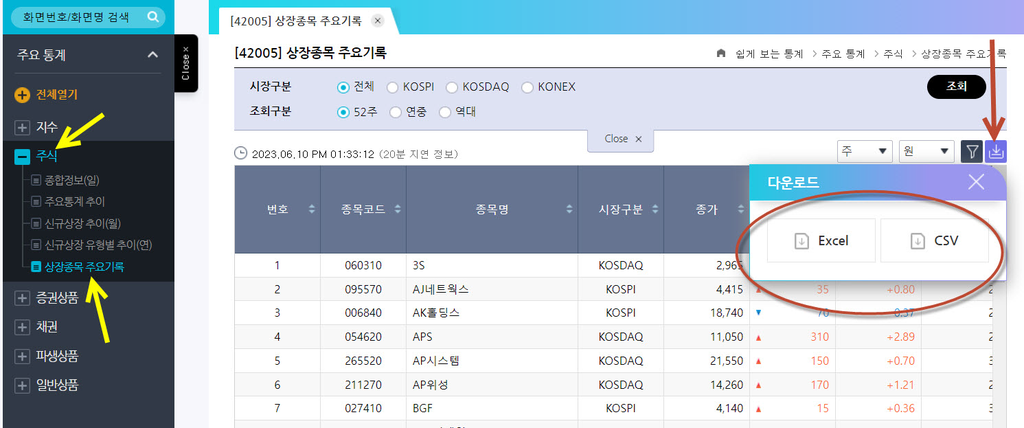

```python
from bs4 import BeautifulSoup
from selenium import webdriver
from selenium.webdriver.common.by import By
from selenium.webdriver.common.keys import Keys
from selenium.webdriver.chrome.options import Options

options = Options()
options.add_argument('--window-size=974,1047')
options.add_argument('--window-position=-7,0')
options.add_experimental_option("detach", True)
```

```python
import os
f_dir = 'stock'
os.makedirs(os.getcwd()+'\\' + f_dir)

driver = webdriver.Chrome(options=options)
URL = 'http://data.krx.co.kr/contents/MDC/MDI/mdiLoader/index.cmd?menuId=MDC0301'
driver.get(URL)
```

```python
driver.find_element(By.LINK_TEXT, '주식').click()
```

```python
driver.find_element(By.LINK_TEXT, '상장종목 주요기록').click()
```

라디오버튼 클릭하기

```python
market = driver.find_element(By.ID, 'mktId_0_1')
market
```

```
<selenium.webdriver.remote.webelement.WebElement (session="a8df5b221deeb593740be215931da989", element="f.A28C6F249B558D955805710119C6A268.d.BBECA1D0EC5798821342173771B24D22.e.278")>
```

```python
# market.click() # 에러 ㅜㅜ
market.send_keys(Keys.ENTER) # 안됨 ㅜㅜ
```

```python
# 자바스크립트 명령을 써야 한다.
driver.execute_script('arguments[0].click()', market)
```

```python
market = driver.find_element(By.CSS_SELECTOR, "[for='mktId_0_1']").click()
```

```python
market.is_selected()
```

```
---------------------------------------------------------------------------
AttributeError                            Traceback (most recent call last)
<ipython-input-45-706a318f4864> in <cell line: 0>()
----> 1 market.is_selected()

AttributeError: 'NoneType' object has no attribute 'is_selected'
```

전체 / KOSPI / KOSDAQ / KONEX 라디오 버튼 선택하기

```python
idx1 = int(input(' 0.전체      1.KOSPI     2.KOSDAQ    3.KONEX  ==> 시장 번호 선택:  '))
idx2 = int(input(' 0.Excel 파일로 저장      1. CSV 파일로 저장   ==> 파일 형식 선택:  '))
```

```python
market_type = ['mktId_0_0','mktId_0_1', 'mktId_0_2', 'mktId_0_3']
market = driver.find_element(By.ID, market_type[idx1])
```

```python
driver.execute_script('arguments[0].click()', market)
market.is_selected()
```

```
True
```

조회 버튼 클릭하기

```python
driver.find_element(By.ID, 'jsSearchButton').click()
```

다운로드 버튼 클릭하기

```python
driver.find_element(By.CLASS_NAME, 'CI-MDI-UNIT-DOWNLOAD').click()
```

파일 버튼 클릭하기

```python
file_type =['Excel', 'CSV']
driver.find_element(By.LINK_TEXT, file_type[idx2]).click()
```

```python
driver.close()
```